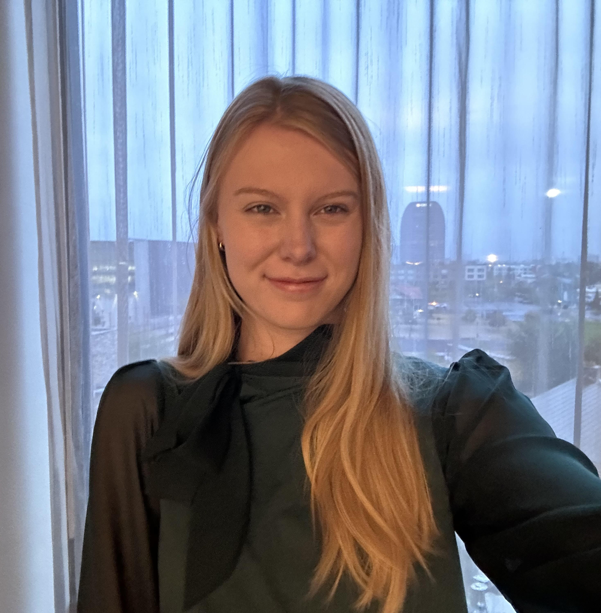

# Sarah Beasley

## Bio

I am a 5th year, PY3 PharmD student at MCPHS University who has recently obtained my Bachelors in Pharmaceutical Sciences with a Minor in Biostatistics from MCPHS and Simmons University. My research interests involve R&D for new and promising drugs with a focus on overall clinical development and conveying that knowledge to providers, integrating my knowledge of clinical care towards a better future for healthcare. I am currently looking for opportunities that allow me to expand my knowledge of pharmacy through practice in different sub-fields to develop my critical thinking and leadership skills.

## Education

**MCPHS University** | Boston, MA

Doctor of Pharmacy | 3.95 GPA | Expected May 2026

Bachelor of Science in Pharmaceutical Sciences | 3.95 GPA | December 2024

**Simmons University** | Boston, MA

Minor in Biostatistics | 4.00 GPA | Obtained May 2022

## Work Experience

**Boston Medical Center (BMC)** | Pharmacy Student Intern | August 2022 - Present

- Patient discharge counseling (Heart Failure, Asthma/COPD, Diabetes, and High-Risk Antibiotics)
- Medication reconciliation
- Sterile and non-sterile compounding
- Pediatric pharmacy operations

**MCPHS University** | Peer Assistant Leader (PAL) | August 2021 - January 2023

**MCPHS University** | Research Assistant | June 2021 - June 2022

**MCPHS University** | Peer Tutor | August 2021 - May 2022

## Introductory Pharmacy Practice Experiences (IPPEs)

**Mount Auburn Hospital** | IPPE Institutional Rotation | June 2024 - July 2024

**Walgreens** | IPPE Community Rotation | August 2023

## Data Science Portfolio

1. **The Best Coffee-Producing Company in The World is…** | February 2022
2. [**Teach Me How to Wrangle**](https://sarahbeasley02.shinyapps.io/Project-2-Learnr/) | March 2022
3. **The Effect of Clean Energy Access on Death Rates Across the Globe (2000-2019)** | May 2022

## Research Experience

**MCPHS University** | Polypharmacy, Hyperpolypharmacy, and Mortality Risk among Older Adults with Cardiovascular Disease | May 2024 - Current

**MCPHS University** | Review of the Efficacy and Safety of Doxycycline for Post-Exposure Prophylaxis of Sexually Transmitted Infections (STIs) | January 2024 - Current

**MCPHS University** | [**A Comparative Study of Fentanyl versus Hydromorphone in Mechanically Ventilated ICU Patients**](https://journals.sagepub.com/doi/10.1177/10600280241300648) | May 2023 - December 2024 | Published December 30th, 2024

## Professional Presentations

**MCPHS SOP-B PharmD Honors Seminar - Research Topic Presentation** | Sodium-glucose co-transporter-2 inhibitors for HFrEF and Their Role in Polypharmacy | October 2024

**MCPHS SOP-B PharmD Honors Seminar - Research Proposal Presentation** | Polypharmacy, Hyperpolypharmacy, and Mortality Risk Among Older Adults with CVD | October 2024

**MCPHS SOP-B PharmD Honors Seminar - Clinical Science Journal Club** | SURMOUNT-4 Outcomes | April 2024

**MCPHS SOP-B PharmD Honors Seminar - Basic Science Journal Club** |Enhancing Fentanyl Antinociception and Preventing Tolerance with α-2 Adrenoceptor Agonists in rats | March 2024

**SCCM Critical Care Conference** | [**Fentanyl versus Hydromorphone in Mechanically Ventilated ICU Patients**](https://journals.lww.com/ccmjournal/fulltext/2024/01001/948__fentanyl_versus_hydromorphone_in_mechanically.893.aspx) | January 2024

- [**Article by MCPHS University about this presentation**](https://www.mcphs.edu/news/pharmacy-student-researcher-targets-critical-care-treatment-options)

**MCPHS SOP-B PharmD Honors Seminar - Topic Presentation** | Pathophysiology of Atopic Dermatitis | November 2023